# W07-Reflection Essay-Introduction to Positron

Author

Asif Kachroo

Published

March 11, 2026

# 1 Introduction

This report reflects on my experience downloading, installing, and exploring Positron while following the workshop activities. It also discusses how Positron compares with RStudio, how AI can be used inside Positron, and my thoughts after exploring GitHub Copilot. In addition, this report is organized using Quarto features to create a more professional and reader-friendly HTML document.

**NoteAbout this report**

This report was created in Quarto and rendered to HTML. It intentionally uses several Quarto features such as section numbering, a table of contents, callout blocks, cross-references, footnotes, tables, lists, blockquotes, and hidden code tools to demonstrate practical formatting skills.

# 2 Essay Prompts and Responses

## 2.1 Downloading and Installing Positron

### 2.1.1 Prompt

Download and Install Positron. As you watch the videos in Step 1 and Step 3, follow the activities in the video and be familiar with Positron.

### 2.1.2 Response

I downloaded and installed Positron, then explored the interface by following the activities shown in the workshop. During the setup process, I created a dedicated project folder, opened that folder as a project, and began working inside a Quarto document. This helped me understand that Positron is designed to make project-based work more organized because everything for the assignment can stay inside one folder, including the `.qmd` file, rendered HTML file, images, and any supporting materials.

As I became more familiar with the platform, I noticed that Positron feels modern and flexible. It combines coding, document writing, and project organization in one space. I also liked that it supports visual editing for Quarto, which makes formatting easier when building reports. This is useful because I can focus on both the content of my writing and the presentation of the final report at the same time.

> One important thing I learned is that Positron is not just a place to run code. It is also a workspace for organizing projects, writing reports, using extensions, and integrating AI tools into a single workflow.

## 2.2 What I Like About Positron Compared with RStudio

### 2.2.1 Prompt

Based on what you learned from Step 1 and Step 3, what do you like about Positron compared with RStudio?

### 2.2.2 Response

What I like most about Positron compared with RStudio is that Positron feels more modern, customizable, and flexible. RStudio is very familiar and works well for R-based tasks, but Positron feels like it gives me a broader workspace. Its layout is clean, and it reminds me of other code editors that support many types of work beyond only R. Because of that, it feels easier to manage writing, coding, file navigation, and extensions in one place.

Another advantage is that Positron makes Quarto work feel natural. I like being able to switch between writing and editing while still keeping the project organized. It also seems more prepared for newer workflows, especially AI-assisted workflows. That matters because many students now use tools that help with writing code, explaining errors, and improving productivity. Positron feels built with that future in mind, while RStudio feels more traditional.

The table below summarizes some of the differences that stood out to me.

Table 1: A brief comparison of Positron and RStudio.

| Feature | Positron | RStudio |
| --- | --- | --- |
| Interface style | Modern and flexible | Familiar and traditional |
| Project workflow | Strong folder/project feel | Strong for R projects |
| AI integration | More naturally integrated | More limited by comparison |
| Quarto experience | Smooth and modern | Good, but more classic |
| Customization | Feels broader | More focused on RStudio ecosystem |

As shown in Table 1, both platforms are useful, but Positron stood out to me because it feels more current and more adaptable to the way students work today.

## 2.3 Using AI Inside Positron

### 2.3.1 Prompt

In Step 4, the video demonstrates how you can use AI. Describe the various ways you can use AI inside Positron. Some are free while others are not.

### 2.3.2 Response

One of the most interesting parts of Positron is the ability to use AI tools inside the workspace. AI can help in several ways. First, it can assist with code completion, which speeds up writing by suggesting lines of code as I type. Second, it can help explain code, which is useful when I do not fully understand what a function, chunk, or script is doing. Third, AI can help debug problems by suggesting what may be causing an error and offering possible fixes. Fourth, it can help generate examples, which is helpful when I know what I want to do but I am not sure how to start.

AI can also be useful for writing tasks. In a Quarto project, AI can help improve wording, reorganize ideas, suggest headings, or explain how to format sections more clearly. That makes it useful not only for coding, but also for building reports that look more polished and professional. Some AI tools are free to access, especially with student programs or free tiers, while others require paid subscriptions depending on the service and level of features offered.

**TipExamples of AI use in Positron**

- Code completion and code suggestions
- Explaining unfamiliar code
- Debugging errors
- Rewriting or improving code
- Generating starter code
- Helping with documentation and report writing
- Assisting with workflow and productivity

## 2.4 AI Tools I Installed or Set Up

### 2.4.1 Prompt

Which AI tools have you installed or set up? Which AI tools did you find beneficial for you?

### 2.4.2 Response

The AI tool I focused on most was GitHub Copilot. It is especially appealing because students can often access it for free through the education program. I found it beneficial because it helps reduce the time spent searching for basic syntax and repetitive code structures. Instead of starting from nothing, I can begin with a suggestion and then edit it to fit my needs. That makes the writing and coding process feel less intimidating.

I also found that AI is most beneficial when used as a support tool rather than as something to rely on completely. For example, it is useful for generating a starting point, checking code logic, or offering another way to phrase an explanation. However, I still need to review everything carefully to make sure the output is accurate and appropriate for the assignment. In that way, AI works best as an assistant, not as a replacement for understanding the material.

## 2.5 GitHub Copilot Education Program

### 2.5.1 Prompt

I strongly recommend using GitHub Copilot, which is free if you apply for an education account. Apply for it and take a screenshot showing you were accepted into the education program.

### 2.5.2 Response

I applied for the GitHub Education program in order to access GitHub Copilot as a student resource. Once approved, this provides a valuable opportunity to use AI-powered assistance without additional cost. This is helpful because it gives students access to a professional tool that can support learning, coding practice, and productivity.

**Screenshot evidence**

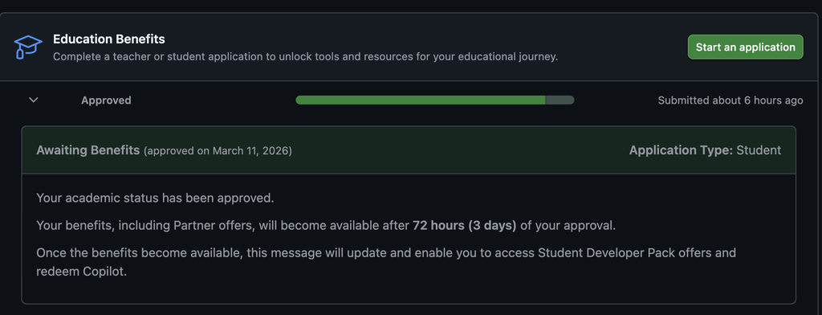

## 2.6 Was GitHub Copilot Helpful or Distracting?

### 2.6.1 Prompt

Play with it and do you find it helpful or distracting? Please elaborate.

### 2.6.2 Response

After trying GitHub Copilot, I found it more helpful than distracting. The most helpful part was how quickly it suggested code patterns and completed repetitive tasks. This saved time and made it easier to keep moving when I already had an idea of what I wanted to do. It was also useful when I needed help remembering syntax or structuring code chunks in Quarto and R.

At the same time, I can see how it could become distracting if I accepted suggestions too quickly without thinking. Sometimes AI suggestions may look correct at first, but they still need to be reviewed carefully. If I rely on them too much, I could miss errors or fail to fully understand the code myself. For that reason, I think GitHub Copilot is most effective when used carefully and critically. Overall, I found it helpful because it speeds up simple tasks and gives useful ideas, but it should always be used with attention and judgment.

## 2.7 Publishing to GitHub Pages

### 2.7.1 Prompt

Publish this report to GitHub Pages and provide a URL to the GitHub Pages for the report. Note that although both GitHub Pages and GitHub repo are online, they are different. GitHub Pages is a website publishing service that hosts the rendered HTML from a QMD file.

### 2.7.2 Response

Publishing this report to GitHub Pages is a useful final step because it turns the Quarto report into a live website that can be shared easily. This is different from simply uploading files to a GitHub repository. A repository stores the project files, while GitHub Pages publishes the rendered output as a viewable webpage.

**ImportantGitHub Pages URL**

# 3 Quarto Features Demonstrated in This Report

## 3.2 Panel Tabset Example

**What I Liked Most**

- Modern interface
- Better AI workflow
- Clean project structure
- Good Quarto support

**What Still Requires Care**

- AI suggestions must be checked
- New interface takes time to learn
- Publishing steps still require attention

**Overall Impression**

Positron feels like a strong tool for students who want one environment for coding, writing, organization, and AI-assisted work.

# 4 Conclusion

Overall, my experience with Positron was positive. It feels modern, organized, and better suited to newer workflows than RStudio in some areas, especially when using Quarto and AI tools together. I found GitHub Copilot especially beneficial because it speeds up basic coding tasks and helps me get started more quickly, although it still requires careful review. Through this assignment, I learned not only how to use Positron and AI tools more effectively, but also how to build a more polished and professional Quarto report.

## Footnotes

[^1]: This screenshot is required as assignment evidence and should be included in the same project folder so it renders correctly in the HTML file.